# 01 — R Fundamentals

**R syntax, data types, data frames, and base plotting using stem cell gene expression data**

| **Duration** | ~2 hours |
| --- | --- |
| **Prerequisites** | None — this is the starting point for beginners |
| **Packages** | `base R (no packages needed)` |

## Learning Objectives

- Understand R syntax: assignment, comments, function calls, and getting help
- Work with R data types and structures: vectors, lists, data frames, and factors
- Index and subset data using [], $, and logical conditions
- Create basic plots with base R graphics
- Read and write CSV files

*Part of the R for Bioinformatics Applications workshop series — Stanford Institute for Stem Cell Biology and Regenerative Medicine*

## Setup

This notebook uses **base R only** — no package installation needed.

We will work with data from a **human embryonic stem cell (ESC) differentiation study** (Koh et al., 2016). The data files should be in the `data/` folder:

- `stemcell_cell_metadata.csv` — metadata for 531 cells across 9 differentiation stages
- `stemcell_expression_top50.csv` — expression counts for the 50 most variable genes across those cells

If you don't have the data folder, set `data_dir` below to the correct path.

```r
# Set the path to the data directory
data_dir <- if (dir.exists("data")) "data" else if (dir.exists("../data")) "../data" else "data"  # Change this if your data is elsewhere

# Verify the files exist
metadata_file <- file.path(data_dir, "stemcell_cell_metadata.csv")
expression_file <- file.path(data_dir, "stemcell_expression_top50.csv")

if (file.exists(metadata_file)) {
  cat("✓ Cell metadata file found\n")
} else {
  cat("✗ Cell metadata file NOT found at:", metadata_file, "\n")
}

if (file.exists(expression_file)) {
  cat("✓ Expression file found\n")
} else {
  cat("✗ Expression file NOT found at:", expression_file, "\n")
}
```

```
✓ Cell metadata file found
✓ Expression file found
```

## Fast-Track Self-Check (Optional)

**Already comfortable with R?** Try these 5 quick exercises. If you can complete them all, skip to **Notebook 02: Data Wrangling with the Tidyverse**.

If you get stuck on any of these, work through the rest of this notebook — it covers everything you need.

**FT-1.** Read `stemcell_cell_metadata.csv` into a data frame called `cell_meta`. How many rows and columns does it have?

**FT-2.** What are the unique values in the `phenotype` column?

**FT-3.** Filter the data frame to only include cells where `total_counts` is greater than 1,000,000. How many cells pass this filter?

**FT-4.** Create a boxplot of `total_features` grouped by `phenotype`.

**FT-5.** Calculate the mean and median of `total_counts` for each phenotype using `tapply()`.

> Solutions are in the companion solutions notebook.

## 1. R Syntax Basics

### Assignment

In R, we assign values to variables using `<-` (the preferred R style) or `=`. Both work, but `<-` is the R convention.

```
gene_name <- "POU5F1"    # character (text)
fold_change <- 2.5       # numeric
is_significant <- TRUE   # logical (TRUE/FALSE)
```

### Comments

Anything after `#` is a comment and is ignored by R:

```
# This is a comment
gene_count <- 500  # This is also a comment
```

### Function Calls

R uses functions extensively. Functions take arguments inside parentheses:

```
print("Hello, stem cells!")
sqrt(16)       # square root
length(c(1,2,3))  # length of a vector
```

### Getting Help

- `?function_name` opens help for a function
- `??search_term` searches all help pages
- `help("function_name")` is equivalent to `?`

```r
# Let's try some basic R operations
# Assignment
gene_name <- "POU5F1"       # OCT4, a key pluripotency factor
fold_change <- 2.5
is_significant <- TRUE
num_genes <- 500

# Print values
print(gene_name)
print(fold_change)
print(is_significant)

# Basic arithmetic
log2_fold_change <- log2(fold_change)  # log2 transform (common in genomics)
cat("log2 fold change:", log2_fold_change, "\n")

# Function calls
cat("Square root of 16:", sqrt(16), "\n")
cat("Number of genes:", num_genes, "\n")

# Getting help (uncomment to try)
# ?log
# ??heatmap
```

```
[1] "POU5F1"
[1] 2.5
[1] TRUE
log2 fold change: 1.321928
Square root of 16: 4
Number of genes: 500
```

## 2. Data Types and Structures

### Basic Data Types

R has several core data types:

| Type | Example | Description |
| --- | --- | --- |
| `numeric` | `2.5`, `100` | Numbers (decimals or integers) |
| `character` | `"POU5F1"` | Text strings |
| `logical` | `TRUE`, `FALSE` | Boolean values |
| `factor` | `factor(c("ESC","MPS"))` | Categorical data with defined levels |

### Vectors

A **vector** is the most common data structure in R — a sequence of elements of the **same type**. Create vectors with `c()` (combine):

```
gene_names <- c("POU5F1", "NANOG", "SOX2", "KLF4")  # character vector
fold_changes <- c(1.5, 2.3, -0.8, 0.5)              # numeric vector
```

### Data Frames

A **data frame** is a table (like a spreadsheet) where each column can be a different type. This is the most common structure for bioinformatics data. We'll load one from CSV shortly.

### Inspecting Objects

- `str()` — structure of an object (most useful!)
- `class()` — the type/class of an object
- `summary()` — statistical summary
- `head()` — first few rows
- `dim()` — dimensions (rows × columns)
- `names()` or `colnames()` — column names

```r
# --- Vectors ---
# Create vectors of stem cell gene data
gene_names <- c("POU5F1", "NANOG", "SOX2", "KLF4", "MYC")
fold_changes <- c(2.5, 3.1, -0.8, 0.5, 1.2)
p_values <- c(0.001, 0.0001, 0.45, 0.03, 0.12)

# Inspect vectors
cat("Gene names:", gene_names, "\n")
cat("Fold changes:", fold_changes, "\n")
cat("Length of gene_names:", length(gene_names), "\n")
cat("Class of fold_changes:", class(fold_changes), "\n")

# Vector operations (element-wise)
log2_fc <- log2(fold_changes)
cat("log2 fold changes:", round(log2_fc, 3), "\n")

# Logical vector
significant <- p_values < 0.05
cat("Significant?", significant, "\n")
```

```
Gene names: POU5F1 NANOG SOX2 KLF4 MYC
Fold changes: 2.5 3.1 -0.8 0.5 1.2
Length of gene_names: 5
Class of fold_changes: numeric
```

```
log2 fold changes: 1.322 1.632 NaN -1 0.263
Significant? TRUE TRUE FALSE TRUE FALSE
```

```r
# --- Factors ---
# Factors represent categorical data — important for experimental groups
phenotypes <- c("H7hESC", "H7hESC", "H7_derived_APS", "H7_derived_MPS", "H7_derived_APS")
phenotype_factor <- factor(phenotypes)

cat("Factor levels:", levels(phenotype_factor), "\n")
cat("Summary (counts per level):\n")
print(table(phenotype_factor))

# Factors are important for DESeq2 and other Bioconductor packages
# where experimental design is specified via factor levels
```

```
Factor levels: H7_derived_APS H7_derived_MPS H7hESC
Summary (counts per level):
phenotype_factor
H7_derived_APS H7_derived_MPS         H7hESC
             2              1              2
```

```r
# --- Lists ---
# Lists can hold different types of elements
gene_info <- list(
  name = "POU5F1",
  aliases = c("OCT4", "OCT3/4"),
  fold_change = 2.5,
  p_value = 0.001,
  is_marker = TRUE
)

# Access list elements with $ or [[ ]]
cat("Gene name:", gene_info$name, "\n")
cat("Aliases:", gene_info$aliases, "\n")
cat("Fold change:", gene_info[["fold_change"]], "\n")

# str() shows the structure of any object
str(gene_info)
```

```
Gene name: POU5F1
Aliases: OCT4 OCT3/4
Fold change: 2.5
List of 5
 $ name       : chr "POU5F1"
 $ aliases    : chr [1:2] "OCT4" "OCT3/4"
 $ fold_change: num 2.5
 $ p_value    : num 0.001
 $ is_marker  : logi TRUE
```

## 3. Reading Data into R

Now let's load our stem cell data. The `read.csv()` function reads CSV files into data frames.

Our data comes from a study of **human H7 embryonic stem cells differentiating into mesoderm lineages** (Koh et al., 2016). The metadata file contains information about each cell, including which differentiation stage it was in.

```r
# Read the cell metadata CSV
cell_meta <- read.csv(metadata_file)

# Inspect the data frame
cat("=== Structure ===\n")
str(cell_meta)

cat("\n=== First 6 rows ===\n")
head(cell_meta)

cat("\n=== Dimensions ===\n")
cat("Rows:", nrow(cell_meta), " Columns:", ncol(cell_meta), "\n")

cat("\n=== Column names ===\n")
colnames(cell_meta)

cat("\n=== Summary ===\n")
summary(cell_meta)
```

```
=== Structure ===
'data.frame':	531 obs. of  5 variables:
 $ cell_id       : chr  "cell_1" "cell_2" "cell_3" "cell_4" ...
 $ phenotype     : chr  "H7hESC" "H7hESC" "H7hESC" "H7hESC" ...
 $ total_counts  : num  2248411 2271617 584682 3191810 2190385 ...
 $ total_features: int  4895 4887 4888 4879 4873 4893 4895 4863 4892 4888 ...
 $ library       : chr  "H7hESC" "H7hESC" "H7hESC" "H7hESC" ...

=== First 6 rows ===
```

A data.frame: 6 × 5

|  | cell_id <chr> | phenotype <chr> | total_counts <dbl> | total_features <int> | library <chr> |
| --- | --- | --- | --- | --- | --- |
| 1 | cell_1 | H7hESC | 2248411.3 | 4895 | H7hESC |
| 2 | cell_2 | H7hESC | 2271617.4 | 4887 | H7hESC |
| 3 | cell_3 | H7hESC | 584682.4 | 4888 | H7hESC |
| 4 | cell_4 | H7hESC | 3191809.6 | 4879 | H7hESC |
| 5 | cell_5 | H7hESC | 2190384.6 | 4873 | H7hESC |
| 6 | cell_6 | H7hESC | 2187288.9 | 4893 | H7hESC |

```
=== Dimensions ===
Rows: 531  Columns: 5

=== Column names ===
```

1. 'cell_id'

2. 'phenotype'

3. 'total_counts'

4. 'total_features'

5. 'library'

```
=== Summary ===
```

```
   cell_id           phenotype          total_counts     total_features
 Length:531         Length:531         Min.   : 390679   Min.   :4265
 Class :character   Class :character   1st Qu.: 952361   1st Qu.:4732
 Mode  :character   Mode  :character   Median :1186395   Median :4851
                                       Mean   :1306938   Mean   :4785
                                       3rd Qu.:1425582   3rd Qu.:4879
                                       Max.   :3540958   Max.   :4897
   library
 Length:531
 Class :character
 Mode  :character
```

```r
# Read the expression data (top 50 most variable genes)
expr_data <- read.csv(expression_file, row.names = 1)  # row.names=1 uses first column as row names

cat("=== Expression data structure ===\n")
cat("Dimensions:", nrow(expr_data), "genes x", ncol(expr_data), "cells\n")
cat("First 5 genes (row names):\n")
print(rownames(expr_data)[1:5])
cat("\nFirst 5 rows, first 5 columns:\n")
expr_data[1:5, 1:5]

cat("\n=== Summary of first few columns ===\n")
summary(expr_data[, 1:4])
```

```
=== Expression data structure ===
Dimensions: 50 genes x 531 cells
First 5 genes (row names):
[1] "ENSG00000198804.2" "ENSG00000198712.1" "ENSG00000210082.2"
[4] "ENSG00000198727.2" "ENSG00000198938.2"

First 5 rows, first 5 columns:
```

A data.frame: 5 × 5

|  | cell_1 <dbl> | cell_2 <dbl> | cell_3 <dbl> | cell_4 <dbl> | cell_5 <dbl> |
| --- | --- | --- | --- | --- | --- |
| ENSG00000198804.2 | 19313.433 | 58178.52 | 9086.786 | 42991.75 | 12428.65 |
| ENSG00000198712.1 | 11857.014 | 28083.70 | 6802.872 | 20067.70 | 21286.17 |
| ENSG00000210082.2 | 24854.721 | 46736.12 | 10962.093 | 36790.91 | 23827.85 |
| ENSG00000198727.2 | 7888.801 | 16513.65 | 4829.260 | 14123.58 | 10974.98 |
| ENSG00000198938.2 | 7774.567 | 17948.93 | 5674.415 | 19873.65 | 10961.43 |

```
=== Summary of first few columns ===
```

```
     cell_1              cell_2             cell_3             cell_4
 Min.   :    8.153   Min.   :   45.05   Min.   :   22.94   Min.   :    3.465
 1st Qu.: 4907.468   1st Qu.: 4843.98   1st Qu.: 1086.51   1st Qu.: 6304.029
 Median : 5853.663   Median : 7800.97   Median : 1682.53   Median : 9305.873
 Mean   : 7623.564   Mean   :10396.57   Mean   : 2492.77   Mean   :12343.405
 3rd Qu.: 8225.071   3rd Qu.:11438.55   3rd Qu.: 2624.13   3rd Qu.:14433.395
 Max.   :31665.585   Max.   :58178.52   Max.   :10962.09   Max.   :61400.819
```

## 4. Indexing and Subsetting

### Data Frame Indexing

Access data in data frames using several methods:

| Syntax | What it does |
| --- | --- |
| `df[i, j]` | Row i, column j |
| `df[i, ]` | Row i (all columns) |
| `df[, j]` | Column j (all rows) |
| `df$col` | A single column by name |
| `df[, "col"]` | Same as above, by name |
| `df[df$col > x, ]` | Rows where col > x (logical indexing) |

### Logical Indexing

This is one of the most powerful patterns in R — filter rows based on a condition:

```
# Get cells with high total counts
high_count_cells <- cell_meta[cell_meta$total_counts > 2000000, ]
```

```r
# --- Basic indexing ---
# Single column with $
cat("First 5 phenotype values:\n")
print(head(cell_meta$phenotype, 5))

# Single column with [ ]
cat("\nFirst 5 total_counts values:\n")
print(head(cell_meta[, "total_counts"], 5))

# Specific rows and columns
cat("\nRows 1-3, columns 'cell_id' and 'phenotype':\n")
print(cell_meta[1:3, c("cell_id", "phenotype")])
```

```
First 5 phenotype values:
[1] "H7hESC" "H7hESC" "H7hESC" "H7hESC" "H7hESC"

First 5 total_counts values:
[1] 2248411.3 2271617.4  584682.4 3191809.6 2190384.6

Rows 1-3, columns 'cell_id' and 'phenotype':
  cell_id phenotype
1  cell_1    H7hESC
2  cell_2    H7hESC
3  cell_3    H7hESC
```

```r
# --- Logical indexing (filtering) ---
# Filter cells with total_counts > 2,000,000
high_count <- cell_meta$total_counts > 2000000
cat("Cells with total_counts > 2M:", sum(high_count), "out of", nrow(cell_meta), "\n")

# Apply the filter
high_count_cells <- cell_meta[high_count, ]
head(high_count_cells)

# Multiple conditions: ESC cells with high feature counts
esc_cells <- cell_meta$phenotype == "H7hESC"
high_feature_esc <- cell_meta[esc_cells & cell_meta$total_features > 4000, ]
cat("\nESC cells with >4000 features:", nrow(high_feature_esc), "\n")
print(head(high_feature_esc))
```

```
Cells with total_counts > 2M: 59 out of 531
```

A data.frame: 6 × 5

|  | cell_id <chr> | phenotype <chr> | total_counts <dbl> | total_features <int> | library <chr> |
| --- | --- | --- | --- | --- | --- |
| 1 | cell_1 | H7hESC | 2248411 | 4895 | H7hESC |
| 2 | cell_2 | H7hESC | 2271617 | 4887 | H7hESC |
| 4 | cell_4 | H7hESC | 3191810 | 4879 | H7hESC |
| 5 | cell_5 | H7hESC | 2190385 | 4873 | H7hESC |
| 6 | cell_6 | H7hESC | 2187289 | 4893 | H7hESC |
| 7 | cell_7 | H7hESC | 2931967 | 4895 | H7hESC |

```
ESC cells with >4000 features: 55
  cell_id phenotype total_counts total_features library
1  cell_1    H7hESC    2248411.3           4895  H7hESC
2  cell_2    H7hESC    2271617.4           4887  H7hESC
3  cell_3    H7hESC     584682.4           4888  H7hESC
4  cell_4    H7hESC    3191809.6           4879  H7hESC
5  cell_5    H7hESC    2190384.6           4873  H7hESC
6  cell_6    H7hESC    2187288.9           4893  H7hESC
```

```r
# --- The subset() function ---
# A more readable way to filter
esc_only <- subset(cell_meta, phenotype == "H7hESC")
cat("Number of ESC cells:", nrow(esc_only), "\n")

# Select specific columns too
esc_summary <- subset(cell_meta, phenotype == "H7hESC",
                      select = c(cell_id, total_counts, total_features))
head(esc_summary)

# Unique values in a column
cat("\nAll unique phenotypes:\n")
print(unique(cell_meta$phenotype))

# Count cells per phenotype
cat("\nCells per phenotype:\n")
print(table(cell_meta$phenotype))
```

```
Number of ESC cells: 55
```

A data.frame: 6 × 3

|  | cell_id <chr> | total_counts <dbl> | total_features <int> |
| --- | --- | --- | --- |
| 1 | cell_1 | 2248411.3 | 4895 |
| 2 | cell_2 | 2271617.4 | 4887 |
| 3 | cell_3 | 584682.4 | 4888 |
| 4 | cell_4 | 3191809.6 | 4879 |
| 5 | cell_5 | 2190384.6 | 4873 |
| 6 | cell_6 | 2187288.9 | 4893 |

```
All unique phenotypes:
[1] "H7hESC"                   "H7_derived_APS"
[3] "H7_derived_MPS"           "H7_derived_DLL1pPXM"
[5] "H7_derived_ESMT"          "H7_derived_Sclrtm"
[7] "H7_derived_D5CntrlDrmmtm" "H7_derived_D2LtM"
[9] "H7_dreived_D2.25_Smtmrs"

Cells per phenotype:

          H7_derived_APS         H7_derived_D2LtM H7_derived_D5CntrlDrmmtm
                      62                       55                       67
     H7_derived_DLL1pPXM          H7_derived_ESMT           H7_derived_MPS
                      74                       43                       22
       H7_derived_Sclrtm  H7_dreived_D2.25_Smtmrs                   H7hESC
                      68                       85                       55
```

```r
# --- Indexing the expression matrix ---
# Get expression of a specific gene across all cells
# (Remember: genes are rows, cells are columns in expr_data)
gene_idx <- 1  # first gene
cat("Gene:", rownames(expr_data)[gene_idx], "\n")
cat("Expression in first 5 cells:\n")
print(expr_data[gene_idx, 1:5])

# Get expression of a specific cell across all genes
cell_idx <- 1
cat("\nExpression of first 10 genes in cell_1:\n")
print(expr_data[1:10, cell_idx])

# Get a subset: first 10 genes, first 5 cells
cat("\nSubmatrix (10 genes x 5 cells):\n")
print(expr_data[1:10, 1:5])
```

```
Gene: ENSG00000198804.2
Expression in first 5 cells:
                    cell_1   cell_2   cell_3   cell_4   cell_5
ENSG00000198804.2 19313.43 58178.52 9086.786 42991.75 12428.65

Expression of first 10 genes in cell_1:
 [1] 19313.433 11857.014 24854.721  7888.801  7774.567  8470.278 31665.585
 [8]  5214.254  5321.612 19242.541

Submatrix (10 genes x 5 cells):
                      cell_1   cell_2    cell_3    cell_4    cell_5
ENSG00000198804.2  19313.433 58178.52  9086.786 42991.749 12428.654
ENSG00000198712.1  11857.014 28083.70  6802.872 20067.705 21286.171
ENSG00000210082.2  24854.721 46736.12 10962.093 36790.906 23827.851
ENSG00000198727.2   7888.801 16513.65  4829.260 14123.583 10974.982
ENSG00000198938.2   7774.567 17948.93  5674.415 19873.653 10961.431
ENSG00000211459.2   8470.278 15715.43  7048.001 10245.524  7247.797
ENSG00000156508.17 31665.585 38752.54  8735.562 61400.819 48025.549
ENSG00000198899.2   5214.254 12113.19  3057.530 11362.654  8080.673
ENSG00000198886.2   5321.612 10827.93  2104.367  9697.099  7274.662
ENSG00000111640.14 19242.541 19221.31  3571.645 30116.706 21445.720
```

## 5. Basic Plotting with Base R

R has built-in plotting functions that are quick and useful for exploration:

- `plot()` — scatter plots
- `hist()` — histograms
- `boxplot()` — box plots (great for comparing groups)
- `barplot()` — bar charts

These are "base R" graphics. Later notebooks will introduce **ggplot2**, which produces more polished, publication-quality figures.

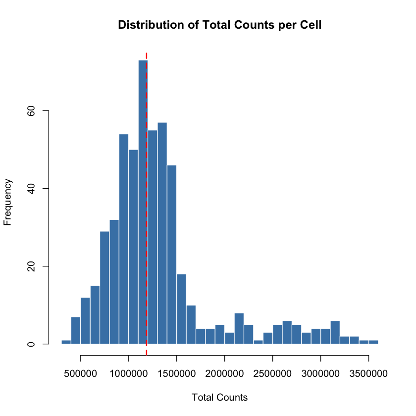

```r
# --- Histogram: distribution of total counts per cell ---
hist(cell_meta$total_counts,
     breaks = 30,
     col = "steelblue",
     main = "Distribution of Total Counts per Cell",
     xlab = "Total Counts",
     border = "white")

# Add a vertical line at the median
abline(v = median(cell_meta$total_counts), col = "red", lwd = 2, lty = 2)
```

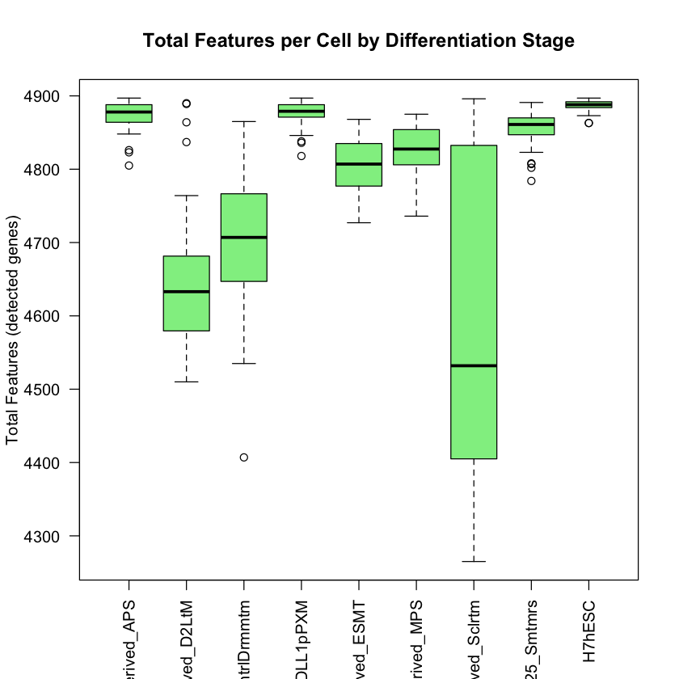

```r
# --- Boxplot: total features by phenotype ---
boxplot(total_features ~ phenotype,
        data = cell_meta,
        las = 2,           # rotate x-axis labels
        col = "lightgreen",
        main = "Total Features per Cell by Differentiation Stage",
        xlab = "",
        ylab = "Total Features (detected genes)")
```

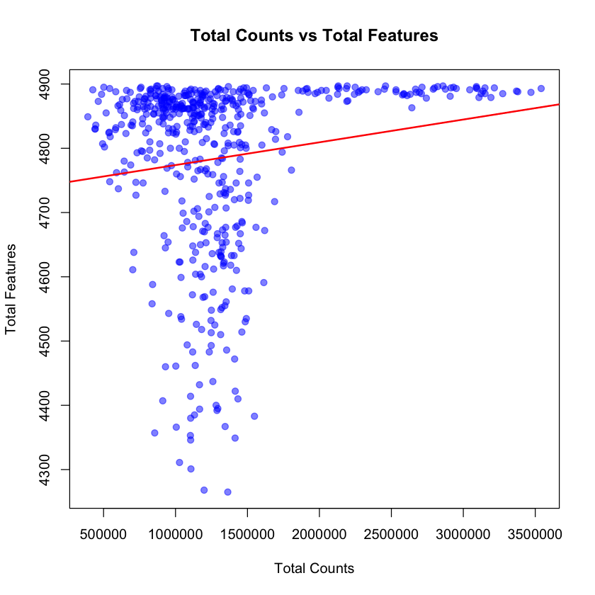

```r
# --- Scatter plot: total_counts vs total_features ---
plot(cell_meta$total_counts, cell_meta$total_features,
     pch = 19,             # solid circles
     col = rgb(0, 0, 1, 0.5),  # semi-transparent blue
     main = "Total Counts vs Total Features",
     xlab = "Total Counts",
     ylab = "Total Features")

# Add a trend line
abline(lm(total_features ~ total_counts, data = cell_meta),
       col = "red", lwd = 2)
```

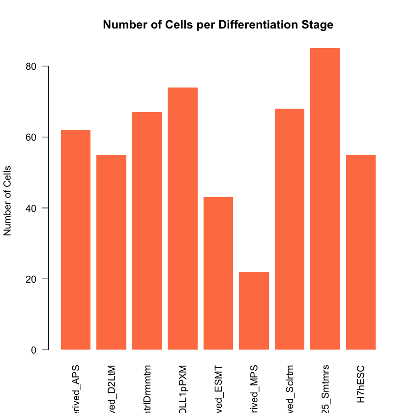

```r
# --- Barplot: cells per phenotype ---
pheno_counts <- table(cell_meta$phenotype)
barplot(pheno_counts,
        las = 2,
        col = "coral",
        main = "Number of Cells per Differentiation Stage",
        ylab = "Number of Cells",
        border = NA)
```

## 6. Writing Data

You can save data frames to CSV files with `write.csv()`:

```
write.csv(my_data, "output_file.csv", row.names = FALSE)
```

Setting `row.names = FALSE` prevents R from adding an extra column with row numbers.

```r
# Example: save the high-count cells to a new CSV
high_count_cells <- subset(cell_meta, total_counts > 2000000)
cat("Saving", nrow(high_count_cells), "high-count cells to CSV\n")

# Write to a file (uncomment to actually write)
# write.csv(high_count_cells, "high_count_cells.csv", row.names = FALSE)

# For this exercise, let's just show what would be written
cat("\nFirst few rows of what would be saved:\n")
print(head(high_count_cells))
```

```
Saving 59 high-count cells to CSV

First few rows of what would be saved:
  cell_id phenotype total_counts total_features library
1  cell_1    H7hESC      2248411           4895  H7hESC
2  cell_2    H7hESC      2271617           4887  H7hESC
4  cell_4    H7hESC      3191810           4879  H7hESC
5  cell_5    H7hESC      2190385           4873  H7hESC
6  cell_6    H7hESC      2187289           4893  H7hESC
7  cell_7    H7hESC      2931967           4895  H7hESC
```

## Exercises

> **Instructions**: Complete the exercises below. Hints are provided in collapsible sections.  
> Check your answers against the companion **Solutions** notebook for this module.

### Exercise 1: Filter cells by total counts

Load `stemcell_cell_metadata.csv` and filter to only include cells where `total_counts` is between 500,000 and 3,000,000. How many cells pass this filter? What are the counts per phenotype in the filtered data?

**💡 Hint**

Use `subset()` with an `&` condition, then `table()` on the phenotype column.

### Exercise 2: Mean expression of a gene across phenotypes

Using the expression data (`expr_data`), pick any gene (row) and calculate the mean expression of that gene for cells belonging to each phenotype.

*Hint: You'll need to match cell IDs between `expr_data` (column names) and `cell_meta` (cell_id column).*

**💡 Hint**

Use `colnames(expr_data)` to get cell IDs, match them to `cell_meta$cell_id`, then use `tapply()` with the phenotype as the grouping factor.

### Exercise 3: Boxplot of total_features by phenotype

Create a boxplot showing the distribution of `total_features` for each phenotype. Color the boxes differently for each phenotype. Add a horizontal line at the overall median.

**💡 Hint**

Use `boxplot()` with a formula. For colors, pass a vector of color names to the `col` argument. Use `abline(h = ...)` for the horizontal line.

### Exercise 4: Read expression CSV, compute row means, write top 10

Read `stemcell_expression_top50.csv`, compute the mean expression for each gene (across all cells), sort genes by mean expression (descending), and write the top 10 genes and their mean expression to a new CSV file called `top10_expressed_genes.csv`.

**💡 Hint**

Use `rowMeans()` on the expression matrix, `sort()` with `decreasing=TRUE`, then create a data frame with `data.frame()` and write with `write.csv()`.

## Wrap-Up

### Key Functions & Concepts

- `<- (assignment)`
- `c() (combine into vector)`
- `factor() (categorical data)`
- `read.csv() / write.csv()`
- `str() / class() / summary() / head()`
- `df[i,j] / df$col / subset() (indexing)`
- `plot() / hist() / boxplot() / barplot()`
- `table() (counting categories)`
- `abline() / lm() (adding trend lines)`

### Next Steps

Proceed to **Notebook 02: Data Wrangling with the Tidyverse**.

### Further Reading

- R for Data Science (free book): r4ds.had.co.nz
- Quick-R: statmethods.net
- R cheat sheets: rstudio.com/resources/cheatsheets/

*This notebook is part of the R for Bioinformatics Applications workshop series.*